# PA1_template.Rmd

The file is downloaded from the web and the data set is read into R

```r
url <- "http://d396qusza40orc.cloudfront.net/repdata%2Fdata%2Factivity.zip"
download.file(url,"activity.zip")
unzip("activity.zip",exdir = "activity")
activity <- read.csv("C:/Users/Sony/Documents/activity/activity.csv")
```

## Calculation of Steps Per day and Histogram of steps per day

### Number of steps taken each day

```r
library(dplyr)
activity1 <- group_by(activity,date)
activity2 <- summarise(activity1, steps = sum(steps,na.rm = TRUE))
activity2 <- as.data.frame(activity2)
head(activity2)
```

```
##         date steps
## 1 2012-10-01     0
## 2 2012-10-02   126
## 3 2012-10-03 11352
## 4 2012-10-04 12116
## 5 2012-10-05 13294
## 6 2012-10-06 15420
```

### Histogram of number of steps taken each day

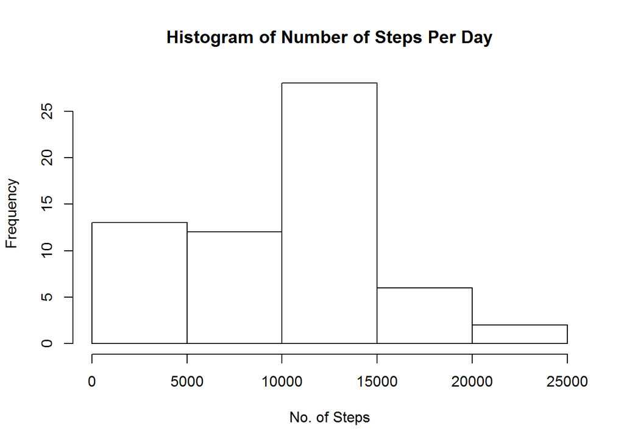

```r
hist(activity2$steps,xlab = "No. of Steps",ylab = "Frequency",main = "Histogram of Number of Steps Per Day")
```

### Mean and Median of total number of steps taken per day

```r
activity3 <- as.data.frame(summarise(activity1, steps_mean = mean(steps,na.rm = TRUE),steps_median = median(steps,na.rm = TRUE)))
tail(activity3)
```

```
##          date steps_mean steps_median
## 56 2012-11-25   41.09028            0
## 57 2012-11-26   38.75694            0
## 58 2012-11-27   47.38194            0
## 59 2012-11-28   35.35764            0
## 60 2012-11-29   24.46875            0
## 61 2012-11-30        NaN           NA
```

```r
mean_steps <- mean(activity2$steps)
median_steps <- median(activity2$steps)
```

The average steps taken per day is 9354.2295082 and the median of steps taken per day is 10395

## Average daily activity pattern

### Time series Plot

The below graph shows the Time series plot of Average Number of steps taken for every 5 minute interval

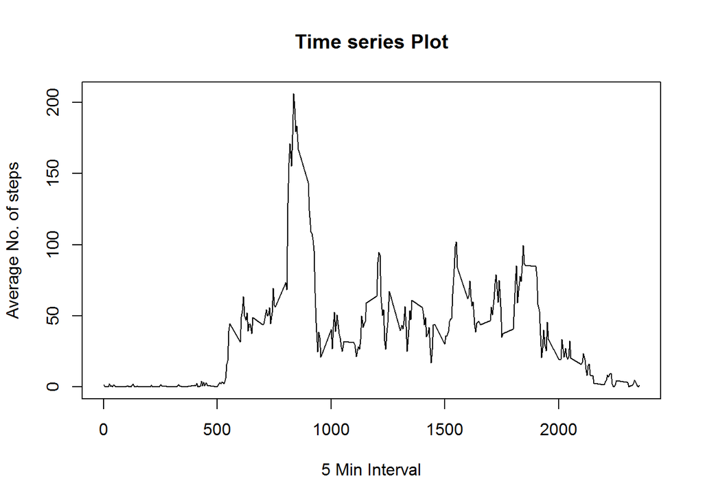

```r
activity4 <- group_by(activity,interval)
activity4 <- as.data.frame(summarise(activity4,steps = mean(steps,na.rm = TRUE)))
plot(activity4$interval,activity4$steps,type = "l",xlab = "5 Min Interval",ylab = "Average No. of steps",main = "Time series Plot")
```

### 5 Min interval with maximum number of steps

```r
interval <- activity4[activity4$steps == max(activity4$steps),]
```

The Interval 835 have the maximum number of steps i.e. 206.1698113